# Session 6 Exercise

Author

Marc Henrion

Published

November 29, 2023

```r
library(tidyverse) # so that we can use ggplot2 and other tidyverse packages
```

## Simulate and write the data

In the code chunk below, a simple dataset is simulated and saved to disk. The exercise did not ask you to do is as part of the quarto document, but I wanted to include this here, so that you can fully reproduce my document.

```r
set.seed(202012) # this will allow you to EXACTLY replicate the same dataset and results

dat<-data.frame(
  type=factor(sample(c("A","B"),size=100,prob=c(0.6,0.4),replace=T)),
  x=rnorm(100,sd=5),
  y=rexp(100)
) %>%
  mutate(
    z=ifelse(type=="A", 2*x-y+5, 1.25*x-0.5*y+1) + rnorm(100,sd=1.25)
  )


if(!dir.exists("data")){dir.create("data",recursive=T)}
save(dat,file="data/dat.rda")

rm(dat) # just so that we have to read it back in again
```

## Load the data

In the chunk below this text commentary, the simulated data is loaded back into R (this is where I would expect your documents to have started).

```r
load("data/dat.rda")

ls() # just to check the data is now loaded
```

```
[1] "dat"
```

## Simple analyses and graphs

### t-test

Let’s do a t-test first, comparing the sample means of variable `z` between the two groups defined by the variable `type`.

```r
resTest<-t.test(z~type,data=dat)
print(resTest)
```

```
    Welch Two Sample t-test

data:  z by type
t = 0.77764, df = 95.303, p-value = 0.4387
alternative hypothesis: true difference in means between group A and group B is not equal to 0
95 percent confidence interval:
 -1.813764  4.149871
sample estimates:
mean in group A mean in group B
       3.359284        2.191230
```

Given that the p-value for this is 0.4387067, we conclude that there is insufficient evidence, at the significance level $\alpha=0.05$ to reject the null hypothesis of equal sample means in both groups.

This conclusion is conditional on the sample means to be approximately normally distributed.

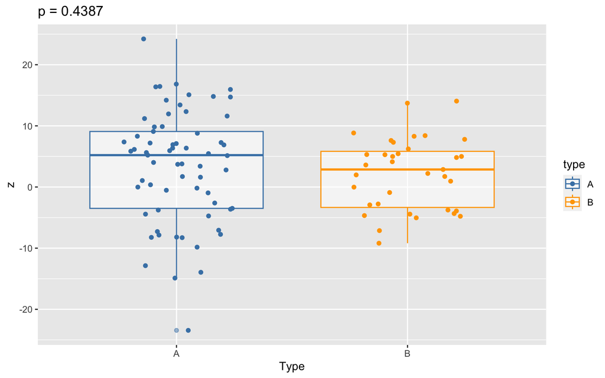

```r
dat %>%
  ggplot(mapping=aes(x=type,y=z,col=type)) +
  geom_boxplot(alpha=0.5) +
  geom_jitter(width=0.25,height=0) +
  xlab("Type") +
  ylab("z") +
  ggtitle(paste(sep="","p = ",round(digits=4,resTest$p.value))) +
  scale_colour_manual(values=c("steelblue","orange"))
```

### Linear regression

```r
resLinMod<-glm(z~x,family=gaussian,data=dat)
print(summary(resLinMod))
```

```
Call:
glm(formula = z ~ x, family = gaussian, data = dat)

Deviance Residuals:
   Min      1Q  Median      3Q     Max
-7.105  -2.180   0.207   2.229   7.620

Coefficients:
            Estimate Std. Error t value Pr(>|t|)
(Intercept)  2.40846    0.31193   7.721 9.93e-12 ***
x            1.66134    0.06903  24.068  < 2e-16 ***
---
Signif. codes:  0 '***' 0.001 '**' 0.01 '*' 0.05 '.' 0.1 ' ' 1

(Dispersion parameter for gaussian family taken to be 9.679085)

    Null deviance: 6555.30  on 99  degrees of freedom
Residual deviance:  948.55  on 98  degrees of freedom
AIC: 514.76

Number of Fisher Scoring iterations: 2
```

```r
p<-summary(resLinMod)$coefficients["x","Pr(>|t|)"]
```

The regression coefficient for x is $\beta1=$ 1.6613386. The associated p-value for the null hypothesis test of $H_0:\beta_1=0$ against $H_1: \beta_1\neq0$ is $p=$ 6.3292832^{-43}. Since this is less than 0.05, we reject $H_0$.

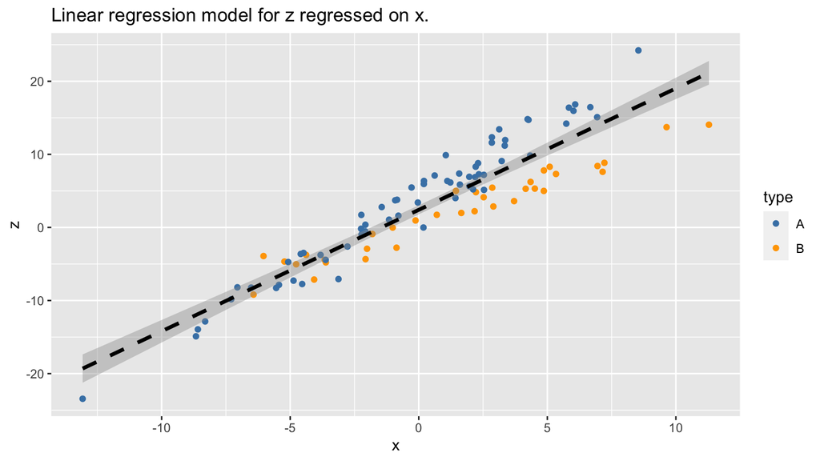

```r
dat %>%
  ggplot(mapping=aes(x=x,y=z,col=type)) +
  geom_point() +
  geom_smooth(method="lm",col="black",lty=2,lwd=1.25) +
  scale_colour_manual(values=c("steelblue","orange")) +
  ggtitle("Linear regression model for z regressed on x.")
```